# BMIN503/EPID600 Final Project

Silvia Canelon

### Overview

The project makes use of the freely-available MIMIC-III Clinical Database to investigate the characteristics of pregnant patients admitted to the Beth Israel Deaconess Medical Center, and their inpatient care. This large dataset of over forty thousand patients admitted to critical care units will be used to identify predictors significantly associated with mortality and/or specific cause of death.

Three faculty/staff being consulted for the project: - Mary Regina Boland; Assistant Professor of Informatics; Department of Biostatistics, Epidemiology, and Informatics - Ray Bai; Postdoctoral Researcher; Department of Biostatistics, Epidemiology, and Informatics - Lena Davidson; Data Analyst; Department of Biostatistics, Epidemiology, and Informatics

### Introduction

The secondary use of Electronic Health Records (EHR) facilitates retrospective research on data collected during the course of patients’ clinical care. The data available through the MIMIC-III Clinical Database provides detailed health-related information collected from a diverse population of patients admitted to intensive care units of a large me dical center, some of whom may have been pregnant at the time of admission. Given the nature of intensive care units, any pregnant patients admitted were likely considered high-risk pregnancies before or at the time of admission. In addition, a subset of these pregnant patients will have deceased or suffered other adverse outcomes during their care, information which can be gleaned through analysis of in-hospital mortality and billing-related information recorded in the EHR. Understanding the characteristics of the pregnant patient population, as well as their care, will shed light on patterns related to adverse outcomes experienced during critical care and hopefully provide preliminary data pertinent to the clinical decison-making process.

The analysis and subsequent interpretation of EHR data is interdisciplinary because it combines domains of the biomedical informatics, epidemiology, biostatistics, and clinical fields. Uncovering potential correlations between patient and patient care information and clinical outcomes involves the use of informatics and statistical analysis skills, whereas epidemiology and clinical domains provide the necessary context for defining/refining the analysis approach and interpreting the results. Consultation with all three faculty/staff has confirmed that adverse outcomes among the patient population admitted to critical care are important to understand from a public health perspective, and likely to not be “rare” events given the intensive care unit context, which allows for standard statistical approaches.

### Methods

The Mimic-III Clinic Database contains de-identified health data records for over 40,000 patients admitted to the Beth Israel Deaconess Medical Center of Boston, Massachusetts from 2001 and 2012. The database includes information on demographics, vital sign measurements, laboratory test results, procedures, medications, caregiver notes, imaging reports, billing-related information, and mortality. Demographic, procedure, mortality, and billing-related information such as International Classification of Disease (ICD) codes, will be used to explore patient characteristics and care while being treated at Beth Isreal Deaconess Medical Center, and mortality studied as an outcome.

#### Connection to server

Packages are loaded and the MIMIC-III dataset is imported from the MySQL database it is stored in.

#### Importing data

This section imports MIMIC-III data from separate tables, most of them including health records and a couple of them including dictionaries for ICD codes.

```r
tic("data import") # takes about 20 secs

rs = dbSendQuery(mimic_iii, "select distinct * from ADMISSIONS;")
data_admissions = fetch(rs, n=-1) #46520
length(unique(data_admissions$SUBJECT_ID))
## [1] 46520

rs = dbSendQuery(mimic_iii, "select distinct * from PATIENTS;")
data_patients = fetch(rs, n=-1) #46520
length(unique(data_patients$SUBJECT_ID))
## [1] 46520

rs = dbSendQuery(mimic_iii, "select distinct * from SERVICES;")
data_services = fetch(rs, n=-1) #46496
length(unique(data_services$SUBJECT_ID))
## [1] 46496

rs = dbSendQuery(mimic_iii, "select distinct * from TRANSFERS;")
data_transfers = fetch(rs, n=-1) #46520
length(unique(data_transfers$SUBJECT_ID))
## [1] 46520

rs = dbSendQuery(mimic_iii, "select distinct * from ICUSTAYS;")
data_icustays = fetch(rs, n=-1) #46476
length(unique(data_icustays$SUBJECT_ID))
## [1] 46476

rs = dbSendQuery(mimic_iii, "select distinct * from DIAGNOSES_ICD;")
data_icd_diag = fetch(rs, n=-1) #46520
length(unique(data_icd_diag$SUBJECT_ID))
## [1] 46520

rs = dbSendQuery(mimic_iii, "select distinct * from PROCEDURES_ICD;")
data_icd_proc = fetch(rs, n=-1) #42214
length(unique(data_icd_proc$SUBJECT_ID))
## [1] 42214

rs = dbSendQuery(mimic_iii, "select distinct * from D_ICD_DIAGNOSES;")
dd_icd_diag = fetch(rs, n=-1)
dim(unique(dd_icd_diag)) #14567
## [1] 14567     4

rs = dbSendQuery(mimic_iii, "select distinct * from D_ICD_PROCEDURES;")
dd_icd_proc = fetch(rs, n=-1)
dim(unique(dd_icd_proc)) #3882
## [1] 3882    4

toc()
## data import: 15.619 sec elapsed
```

#### Data tyding

##### Trimming/formatting data

This section selects only the relevant variables from admissionss, expired patient, services, and ICU stay data, and adjusts variable class as needed (namely to `date` or `numeric` classes).

```r
# trimming and formatting admissions data
admissions <- data_admissions %>%
  select(-(ADMISSION_LOCATION:DISCHARGE_LOCATION),-(EDREGTIME:DIAGNOSIS),
         -(LANGUAGE:MARITAL_STATUS),-HAS_CHARTEVENTS_DATA) %>%
  mutate(ADMITTIME = as.Date(ADMITTIME),
         DISCHTIME = as.Date(DISCHTIME))

# formatting dates of death in expired patient data
patients_dod <- data_patients %>% select(-DOD,-DOD_SSN) %>% filter(EXPIRE_FLAG == 1) %>%
  mutate(DOD_HOSP = as.Date(DOD_HOSP))
# joining expired patient data with larger patients data frame
patients <- left_join(data_patients %>% select(-(DOD:DOD_SSN)), patients_dod) %>%
  mutate(DOB = as.Date(DOB))

# trimmming and formatting services data
services <- data_services %>% select(-(TRANSFERTIME:PREV_SERVICE))

# trimmming and formatting ICU stay data
icustays <- data_icustays %>% select(-(FIRST_WARDID:LAST_WARDID)) %>%
  mutate(INTIME = as.Date(INTIME),
         OUTTIME = as.Date(OUTTIME),
         LOS = as.numeric(LOS))
```

##### Joining data

This section joins diagnosis and procedure records to the ICD diagnosis and procedure data dictionaries by `ICD9_CODE`.

```r
# joining diagnosis and procedure data to ICD codes
icd_diag <- left_join(data_icd_diag, dd_icd_diag %>% select(-ROW_ID), by = "ICD9_CODE")
icd_proc <- left_join(data_icd_proc, dd_icd_proc %>% select(-ROW_ID), by = "ICD9_CODE")

# counting diagnosis records with and without proper ICD9_CODEs from the data dictionary
dim(icd_diag) #651047
## [1] 651047      7
length(unique(icd_diag$SUBJECT_ID)) #46520
## [1] 46520
diag_w_code <- icd_diag %>% filter(!(is.na(SHORT_TITLE)))
dim(diag_w_code) #634709
## [1] 634709      7
diag_wo_code <- icd_diag %>% filter(is.na(SHORT_TITLE))
dim(diag_wo_code) #16338
## [1] 16338     7

# counting procedure records with and without proper ICD9_CODEs from the data dictionary
dim(icd_proc) #240095
## [1] 240095      7
length(unique(icd_proc$SUBJECT_ID)) #42214
## [1] 42214
proc_w_code <- icd_proc %>% filter(!(is.na(SHORT_TITLE)))
dim(proc_w_code) #237948
## [1] 237948      7
proc_wo_code <- icd_proc %>% filter(is.na(SHORT_TITLE))
dim(proc_wo_code) #2147
## [1] 2147    7
```

This section joins admission records to a table containing patient data, and then to Intensive Care Unit (ICU) stay records. It also record dates and dates of birth to calculate the age at the time of admission (`AGE_ADM`), hospital discharge (`AGE_DIS`), and hospital death (`AGE_DOD`).

```r
# joining admission data to adult patient data
patients_adm <- left_join(admissions, patients %>% select(-ROW_ID), by = "SUBJECT_ID") %>%
  mutate(AGE_ADM = round(as.duration(DOB %--% ADMITTIME)/dyears(1),2), # age at admission
         AGE_DIS = round(as.duration(DOB %--% DISCHTIME)/dyears(1),2), # age at discharge
         AGE_DOD = round(as.duration(DOB %--% DOD_HOSP)/dyears(1),2)) %>% # age at death
  filter(AGE_ADM >= 18) # age at admission was used to select records from only adults

# joining ICU data to admission+patient data
patients_adm_icu <- left_join(patients_adm, icustays %>% select(SUBJECT_ID, HADM_ID, LOS),
                              by = c("SUBJECT_ID","HADM_ID")) %>% rename(LOS_ICU = LOS)

# joining ICD data to admission+patient+ICU data
patients_adm_icu_diag <- left_join(patients_adm_icu, icd_diag %>% select(-ROW_ID),
                               by = c("SUBJECT_ID","HADM_ID"))
patients_adm_icu_proc <- left_join(patients_adm_icu, icd_proc %>% select(-ROW_ID),
                               by = c("SUBJECT_ID","HADM_ID"))
```

##### Recoding data

This section identifies the different categories present in the dataset `ETHNICITY` variable and then recodes those that could reasonably be binned together in order to increase the sample size in each major ethnicity category. For example, ethnicity subcategory `ASIAN - JAPANESE` was recoded as `ASIAN`. It should be noted that with a large enough dataset with larger representation of each ethnicity subcategory, important nuance could be captured between these subpopulations that experience different experiences with the health care system. This is not possible with datasets that, by default, allow for only a handful of ethnicity categories. Produces primary data frame `patients_recoded`.

```r
# identifying the frequency different ethnicity categories present in the dataset
cat_ethnicity <- table(patients_adm_icu$ETHNICITY) %>% data.frame()

# binning subethnicities into larger ethnicity categories
patients_recoded <- patients_adm_icu %>%
  mutate(ETHNICITY_BROAD = as.factor(ETHNICITY)) %>%
  mutate(ETHNICITY_BROAD = recode(ETHNICITY_BROAD,
                                  "AMERICAN INDIAN/ALASKA NATIVE" = "AIAN",
                                  "AMERICAN INDIAN/ALASKA NATIVE FEDERALLY RECOGNIZED TRIBE" = "AIAN",
                                  "ASIAN - ASIAN INDIAN" = "ASIAN",
                                  "ASIAN - CAMBODIAN" = "ASIAN",
                                  "ASIAN - CHINESE" = "ASIAN",
                                  "ASIAN - FILIPINO" = "ASIAN",
                                  "ASIAN - JAPANESE" = "ASIAN",
                                  "ASIAN - KOREAN" = "ASIAN",
                                  "ASIAN - OTHER" = "ASIAN",
                                  "ASIAN - THAI" = "ASIAN",
                                  "ASIAN - VIETNAMESE" = "ASIAN",
                                  "BLACK/AFRICAN" = "BLACK",
                                  "BLACK/AFRICAN AMERICAN" = "BLACK",
                                  "BLACK/CAPE VERDEAN" = "BLACK",
                                  "BLACK/HAITIAN" = "BLACK",
                                  "HISPANIC OR LATINO" = "HISPANIC",
                                  "HISPANIC/LATINO - CENTRAL AMERICAN (OTHER)" = "HISPANIC",
                                  "HISPANIC/LATINO - COLOMBIAN" = "HISPANIC",
                                  "HISPANIC/LATINO - CUBAN" = "HISPANIC",
                                  "HISPANIC/LATINO - DOMINICAN" = "HISPANIC",
                                  "HISPANIC/LATINO - GUATEMALAN" = "HISPANIC",
                                  "HISPANIC/LATINO - HONDURAN" = "HISPANIC",
                                  "HISPANIC/LATINO - MEXICAN" = "HISPANIC",
                                  "HISPANIC/LATINO - PUERTO RICAN" = "HISPANIC",
                                  "HISPANIC/LATINO - SALVADORAN" = "HISPANIC",
                                  "NATIVE HAWAIIAN OR OTHER PACIFIC ISLANDER" = "NHPI",
                                  "WHITE - BRAZILIAN" = "WHITE",
                                  "WHITE - EASTERN EUROPEAN" = "WHITE",
                                  "WHITE - OTHER EUROPEAN" = "WHITE",
                                  "WHITE - RUSSIAN" = "WHITE"))

# identifying the frequency of different ethnicity categories after the recoding efforts
cat_ethnicity_broad <- table(patients_recoded$ETHNICITY_BROAD) %>% data.frame()
```

This section adjusts the class of certain variables in the new `patients_recoded` data frame and recodes mortality and age variables. The MIMIC-III dataset shifts all dates to protect patient confidentiality and all patients 89 years or older are marked as being 300 years or older. These 300 year old ages were adjusted to 89 for easier interpretation.

```r
# formatting/recoding insurance, gender, hospital death, and age variables
patients_recoded <- patients_recoded %>%
  mutate(ADMISSION_TYPE = as.factor(ADMISSION_TYPE),
         GENDER = factor(GENDER),
         MORTALITY = factor(HOSPITAL_EXPIRE_FLAG, levels = c(0,1), labels = c("LIVED","DIED")),
         AGE_ADM = ifelse(AGE_ADM > 300, 89, AGE_ADM),
         AGE_DIS = ifelse(AGE_DIS > 300, 89, AGE_DIS),
         AGE_DOD = ifelse(AGE_DOD > 300, 89, AGE_DOD),
         INSURANCE = as.factor(INSURANCE)) %>%
  mutate(INSURANCE = recode(INSURANCE,
                            "Government" = "GOV", "Medicaid" = "MEDICAID","Medicare" = "MEDICARE",
                            "Private" = "PRIVATE", "Self Pay" = "SELF PAY"))

# trimming data to remove variables no longer needed
patients_recoded <- patients_recoded %>% select(-ETHNICITY, -HOSPITAL_EXPIRE_FLAG, -EXPIRE_FLAG)
```

#### Delivery codes

This section imports tables of ICD codes for delivery diagnoses and procedures.

```r
# Importing all delivery DIAGNOSIS ICD9 codes
codes_delivery_diag = read.csv("delivery_diag_codes_SPC.csv", header = F) %>%
  mutate(V1 = as.character(V1))
head(codes_delivery_diag)
##       V1   V2                       V3                                                                                             V4
## 1    650 ICD9          Normal delivery                                                                                Normal delivery
## 2 651.01 ICD9 Twin pregnancy-delivered                     Twin pregnancy, delivered, with or without mention of antepartum condition
## 3 651.11 ICD9  Triplet pregnancy-deliv                  Triplet pregnancy, delivered, with or without mention of antepartum condition
## 4 651.13 ICD9  Triplet preg-antepartum                                        Triplet pregnancy, antepartum condition or complication
## 5 651.21 ICD9  Quadruplet preg-deliver               Quadruplet pregnancy, delivered, with or without mention of antepartum condition
## 6 651.81 ICD9 Multi gestat NEC-deliver Other specified multiple gestation, delivered, with or without mention of antepartum condition

# adjusting the CODE variable to remove the decimal point
codes_delivery_diag_icd9 <- codes_delivery_diag %>% filter(V2 == "ICD9") %>%
  mutate(CODE = str_remove(V1, "\\.")) %>% select(CODE)
head(codes_delivery_diag_icd9)
##    CODE
## 1   650
## 2 65101
## 3 65111
## 4 65113
## 5 65121
## 6 65181

# Importing all delivery PROCEDURE ICD9 codes
codes_delivery_proc = read.csv("delivery_proc_codes_SPC.csv", header = F)
head(codes_delivery_proc)
##      V1   V2                                    V3                                    V4
## 1    72 ICD9  Forceps, vacuum, and breech delivery
## 2  72.0 ICD9                 Low forceps operation                 Low forceps operation
## 3  72.1 ICD9              Low forceps w episiotomy Low forceps operation with episiotomy
## 4  72.2 ICD9                 Mid forceps operation
## 5 72.21 ICD9              Mid forceps w episiotomy Mid forceps operation with episiotomy
## 6 72.29 ICD9                    Mid forceps op NEC           Other mid forceps operation

# adjusting the CODE variable to remove the decimal point
codes_delivery_proc_icd9 <- codes_delivery_proc %>% filter(V2 == "ICD9") %>%
  mutate(CODE = str_remove(V1, "\\.")) %>% select(CODE)
head(codes_delivery_proc_icd9)
##   CODE
## 1   72
## 2  720
## 3  721
## 4  722
## 5 7221
## 6 7229
```

This section identifies patient records assigned a delivery ICD diagnosis or procedure code.

```r
# Records with delivery diagnosis codes
records_delivery_diag = icd_diag %>% filter(ICD9_CODE %in% codes_delivery_diag_icd9$CODE) %>%
  mutate(CODE_TYPE = "DIAGNOSIS")
head(records_delivery_diag)
##   ROW_ID SUBJECT_ID HADM_ID SEQ_NUM ICD9_CODE             SHORT_TITLE                                                                                                     LONG_TITLE CODE_TYPE
## 1  35646       3193  191836       8     65421 Prev c-delivery-delivrd                         Previous cesarean delivery, delivered, with or without mention of antepartum condition DIAGNOSIS
## 2  35650       3193  191836      12      V270 Deliver-single liveborn                                                                           Outcome of delivery, single liveborn DIAGNOSIS
## 3  30715       2735  118482       1     66551 Ob inj pelv org NEC-del                      Other injury to pelvic organs, delivered, with or without mention of antepartum condition DIAGNOSIS
## 4  30717       2735  118482       3      V270 Deliver-single liveborn                                                                           Outcome of delivery, single liveborn DIAGNOSIS
## 5  30719       2735  118482       5     66582 Ob trauma NEC-del w p/p                         Other specified obstetrical trauma, delivered, with mention of postpartum complication DIAGNOSIS
## 6  54400       4883  123172       5     65641 Intrauter death-deliver Intrauterine death, affecting management of mother, delivered, with or without mention of antepartum condition DIAGNOSIS

# Records with delivery procedure codes
records_delivery_proc = icd_proc %>% filter(ICD9_CODE %in% codes_delivery_proc_icd9$CODE) %>%
  mutate(CODE_TYPE = "PROCEDURE")
head(records_delivery_proc)
##   ROW_ID SUBJECT_ID HADM_ID SEQ_NUM ICD9_CODE            SHORT_TITLE                    LONG_TITLE CODE_TYPE
## 1    292      23752  163187       1       741 Low cervical c-section Low cervical cesarean section PROCEDURE
## 2  10272      21422  192289       1       741 Low cervical c-section Low cervical cesarean section PROCEDURE
## 3  13185      26539  132551       1       741 Low cervical c-section Low cervical cesarean section PROCEDURE
## 4  31067       7231  129781       1       740    Classical c-section    Classical cesarean section PROCEDURE
## 5  39750       6416  183789       1       741 Low cervical c-section Low cervical cesarean section PROCEDURE
## 6  52205       4661  123365       1       741 Low cervical c-section Low cervical cesarean section PROCEDURE

# Joining diagnosis delivery and procedure codes
records_delivery <- rbind(records_delivery_diag, records_delivery_proc) %>% unique()
length(unique(records_delivery$ROW_ID)) #203
## [1] 203
length(unique(records_delivery$SUBJECT_ID)) #48
## [1] 48
length(unique(records_delivery$HADM_ID)) #48
## [1] 48
```

- There are 203 delivery diagnosis or procedure records from 48 patients

#### C-section codes

This section imports tables of ICD codes for cesarean section (C-section) procedures.

```r
# Importing all C-section PROCEDURE codes
codes_csection_proc = read.csv("csection_proc_codes_SPC.csv", header = F)
head(codes_csection_proc)
##     V1   V2                                    V3                                         V4
## 1  74  ICD9 Cesarean section and removal of fetus
## 2 74.0 ICD9                   Classical c-section                 Classical cesarean section
## 3 74.1 ICD9                Low cervical c-section              Low cervical cesarean section
## 4 74.2 ICD9                Extraperitoneal c-sect           Extraperitoneal cesarean section
## 5 74.4 ICD9                  Cesarean section NEC   Cesarean section of other specified type
## 6 74.9 ICD9                  Cesarean section NOS Other cesarean section of unspecified type
codes_csection_proc_icd9 <- codes_csection_proc %>% filter(V2 == "ICD9") %>%
  mutate(CODE = str_remove(V1, "\\.")) %>% select(CODE)
head(codes_csection_proc_icd9)
##   CODE
## 1  74
## 2  740
## 3  741
## 4  742
## 5  744
## 6  749
```

This section identifies patient records assigned a C-section ICD procedure code.

```r
# Records with C-section procedure codes
records_csection_proc = icd_proc %>% filter(ICD9_CODE %in% codes_csection_proc_icd9$CODE) %>%
  mutate(CODE_TYPE = "PROCEDURE")
head(records_csection_proc)
##   ROW_ID SUBJECT_ID HADM_ID SEQ_NUM ICD9_CODE            SHORT_TITLE                    LONG_TITLE CODE_TYPE
## 1    292      23752  163187       1       741 Low cervical c-section Low cervical cesarean section PROCEDURE
## 2  10272      21422  192289       1       741 Low cervical c-section Low cervical cesarean section PROCEDURE
## 3  13185      26539  132551       1       741 Low cervical c-section Low cervical cesarean section PROCEDURE
## 4  31067       7231  129781       1       740    Classical c-section    Classical cesarean section PROCEDURE
## 5  39750       6416  183789       1       741 Low cervical c-section Low cervical cesarean section PROCEDURE
## 6  52205       4661  123365       1       741 Low cervical c-section Low cervical cesarean section PROCEDURE

records_csection <- records_csection_proc

length(unique(records_csection$ROW_ID)) #38
## [1] 38
length(unique(records_csection$SUBJECT_ID)) #37
## [1] 37
length(unique(records_csection$HADM_ID)) #37
## [1] 37
```

- There are 38 csection procedure codes from 37 patients

#### Joining delivery and C-section

This section adds binary variables to the primary `patients_recoded` dataframe to account for the presence/absence of a delivery or C-section ICD code.

```r
# adding in variables for delivery and csection
patients_recoded <- patients_recoded %>%
  mutate(DELIVERY = ifelse(HADM_ID %in% records_delivery$HADM_ID, "DELIVERY", "NO DELIVERY"),
         CSECTION = ifelse(HADM_ID %in% records_csection$HADM_ID, "CSECTION", "NO CSECTION")) %>%
  mutate(DELIVERY = as.factor(DELIVERY),
         CSECTION = as.factor(CSECTION))
```

### Results

#### Descriptive information

```r
# trimmming data to only the predictor variables of interest
patients_recoded_trim <- patients_recoded %>%
  select(ADMISSION_TYPE,INSURANCE,GENDER,AGE_ADM,AGE_DOD,LOS_ICU,ETHNICITY_BROAD,DELIVERY,CSECTION, MORTALITY) %>% unique()
dim(unique(patients_recoded_trim)) #54362 unique records and 10 variables of interest
## [1] 54362    10

# ggpairs(patients_recoded_trim, mapping = aes(col = MORTALITY), columns = c("GENDER","ETHNICITY_BROAD", "AGE_ADM","AGE_DOD"))
```

#### Visualization

```r
# Penn and DBEI/CCEB colors
PennBlue = "#1e376c" #DBEI/CCEB
PennRed = "#a90533" #DBEI/CCEB
DarkBlue = "#2e5d97" #DBEI/CCEB
LightBlue = "#2e9ad5" #DBEI/CCEB
Purple = "#7e6b94" #DBEI
Orange = "#d47d3a" #Excel orange
Yellow = "#efbf2c" #Excel yellow
DeptYellow = "ffd400" #DBEI/CCEB yellow
Beige = "#e8eade" #DBEI/CCEB
OrangeRed = "#fef3742" #DBEI
LightRed = "#d99792" #DBEI
Green = "#83944e" #CCEB
Grey = "#999999"
```

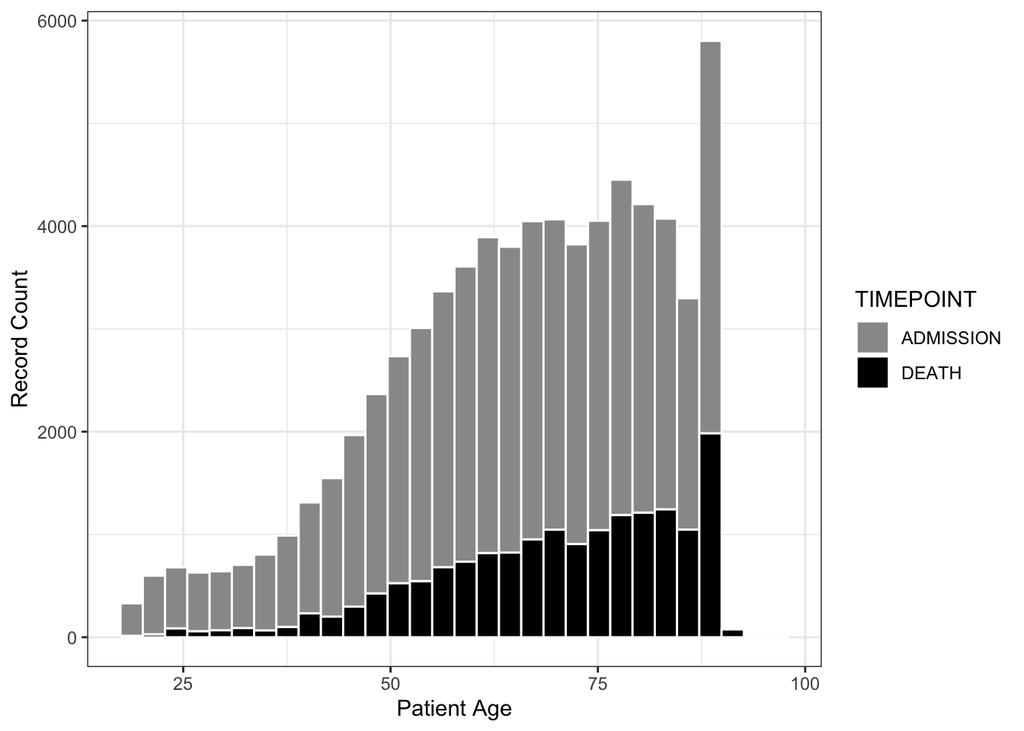

```r
# gathering different age variables into a single variable "AGE" and corresponding age type "TIMEPOINT"
pats_age <- patients_recoded_trim %>%
  gather(AGE_ADM:AGE_DOD, key = "TIMEPOINT", value = "AGE") %>%
  mutate(TIMEPOINT = recode(TIMEPOINT, "AGE_ADM" = "ADMISSION", "AGE_DOD" = "DEATH"))
head(pats_age)
##   ADMISSION_TYPE INSURANCE GENDER LOS_ICU       ETHNICITY_BROAD    DELIVERY    CSECTION MORTALITY TIMEPOINT   AGE
## 1      EMERGENCY   PRIVATE      F  1.1438                 WHITE NO DELIVERY NO CSECTION     LIVED ADMISSION 64.97
## 2       ELECTIVE  MEDICARE      M  1.2641                 WHITE NO DELIVERY NO CSECTION     LIVED ADMISSION 71.18
## 3      EMERGENCY  MEDICARE      M  1.1862                 WHITE NO DELIVERY NO CSECTION     LIVED ADMISSION 75.30
## 4      EMERGENCY   PRIVATE      M  0.5124                 WHITE NO DELIVERY NO CSECTION     LIVED ADMISSION 39.04
## 5      EMERGENCY   PRIVATE      M  3.5466                 WHITE NO DELIVERY NO CSECTION     LIVED ADMISSION 58.99
## 6      EMERGENCY  MEDICARE      M  2.1407 UNKNOWN/NOT SPECIFIED NO DELIVERY NO CSECTION     LIVED ADMISSION 72.05

# creating a histogram for AGE at admission and at death
ggplot(pats_age, aes(x = AGE), bins = 50) +
  geom_histogram(aes(fill = TIMEPOINT), color = "white") +
  scale_fill_manual(values = c(Grey, "black")) +
  theme_bw() +
  labs(y = "Record Count", x = "Patient Age")
```

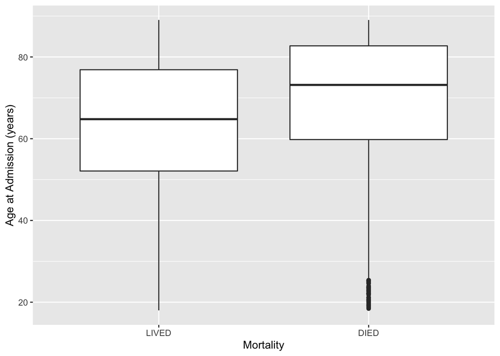

```r
# AGE_ADM descriptive information
table(patients_recoded_trim$AGE_ADM > 89) # only 36 records with patient age > 89
##
## FALSE  TRUE
## 54326    36

summary(patients_recoded_trim$AGE_ADM) # mean 64.02
##    Min. 1st Qu.  Median    Mean 3rd Qu.    Max.
##   18.01   52.90   65.78   64.02   77.78   89.06
sd(patients_recoded_trim$AGE_ADM) # std dev 16.9921
## [1] 16.9921

# AGE_DOD descriptive information
age_dod <- patients_recoded_trim %>% filter(!(is.na(AGE_DOD)))
summary(age_dod$AGE_DOD) # mean 70.13
##    Min. 1st Qu.  Median    Mean 3rd Qu.    Max.
##   18.46   60.33   72.43   70.13   82.42   95.85
sd(age_dod$AGE_DOD) # std dev 14.86695
## [1] 14.86695

# AGE_ADM as predictor
ggplot(data = patients_recoded_trim, aes(x = MORTALITY, y = AGE_ADM)) +
    geom_boxplot() +
  labs(y = "Age at Admission (years)", x = "Mortality")
```

```r
# AGE_ADM as a predictor
summary((glm(MORTALITY ~ AGE_ADM, data = patients_recoded_trim, family = binomial()))) # p-value <2e-16
##
## Call:
## glm(formula = MORTALITY ~ AGE_ADM, family = binomial(), data = patients_recoded_trim)
##
## Deviance Residuals:
##     Min       1Q   Median       3Q      Max
## -0.6645  -0.5633  -0.4764  -0.3854   2.5644
##
## Coefficients:
##               Estimate Std. Error z value Pr(>|z|)
## (Intercept) -3.7335953  0.0623189  -59.91   <2e-16 ***
## AGE_ADM      0.0262223  0.0008791   29.83   <2e-16 ***
## ---
## Signif. codes:  0 '***' 0.001 '**' 0.01 '*' 0.05 '.' 0.1 ' ' 1
##
## (Dispersion parameter for binomial family taken to be 1)
##
##     Null deviance: 40095  on 54361  degrees of freedom
## Residual deviance: 39114  on 54360  degrees of freedom
## AIC: 39118
##
## Number of Fisher Scoring iterations: 5
```

- AGE_ADM was positively associated with MORTALITY with p-value <2e-16

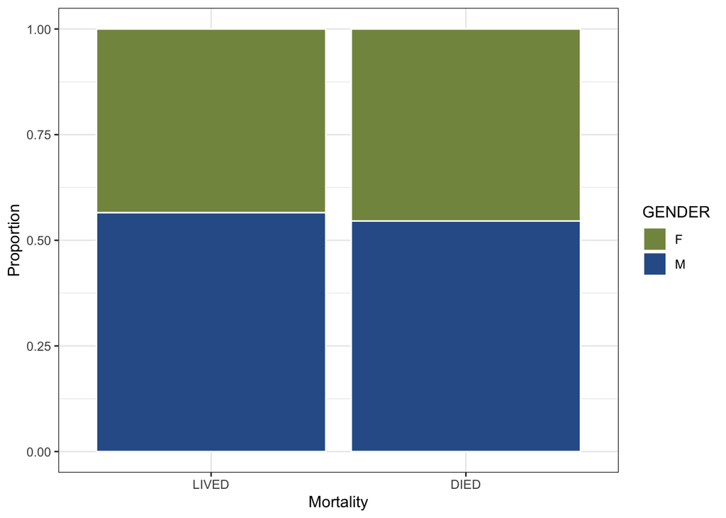

```r
ggplot(data = patients_recoded_trim, aes(x = MORTALITY, fill = GENDER)) +
    geom_bar(position = "fill", color = "white") +
  scale_fill_manual(values = c(Green, DarkBlue)) +
  theme_bw() +
  labs(y = "Proportion", x = "Mortality")
```

```r
# GENDER as predictor
summary((glm(MORTALITY ~ GENDER, data = patients_recoded_trim, family = binomial()))) # 0.00226
##
## Call:
## glm(formula = MORTALITY ~ GENDER, family = binomial(), data = patients_recoded_trim)
##
## Deviance Residuals:
##     Min       1Q   Median       3Q      Max
## -0.5185  -0.5185  -0.4992  -0.4992   2.0708
##
## Coefficients:
##             Estimate Std. Error z value Pr(>|z|)
## (Intercept) -1.93881    0.01957 -99.075  < 2e-16 ***
## GENDERM     -0.08071    0.02643  -3.053  0.00226 **
## ---
## Signif. codes:  0 '***' 0.001 '**' 0.01 '*' 0.05 '.' 0.1 ' ' 1
##
## (Dispersion parameter for binomial family taken to be 1)
##
##     Null deviance: 40095  on 54361  degrees of freedom
## Residual deviance: 40085  on 54360  degrees of freedom
## AIC: 40089
##
## Number of Fisher Scoring iterations: 4
```

- There is a relationship between GENDER and MORTALITY with p-value 0.00226

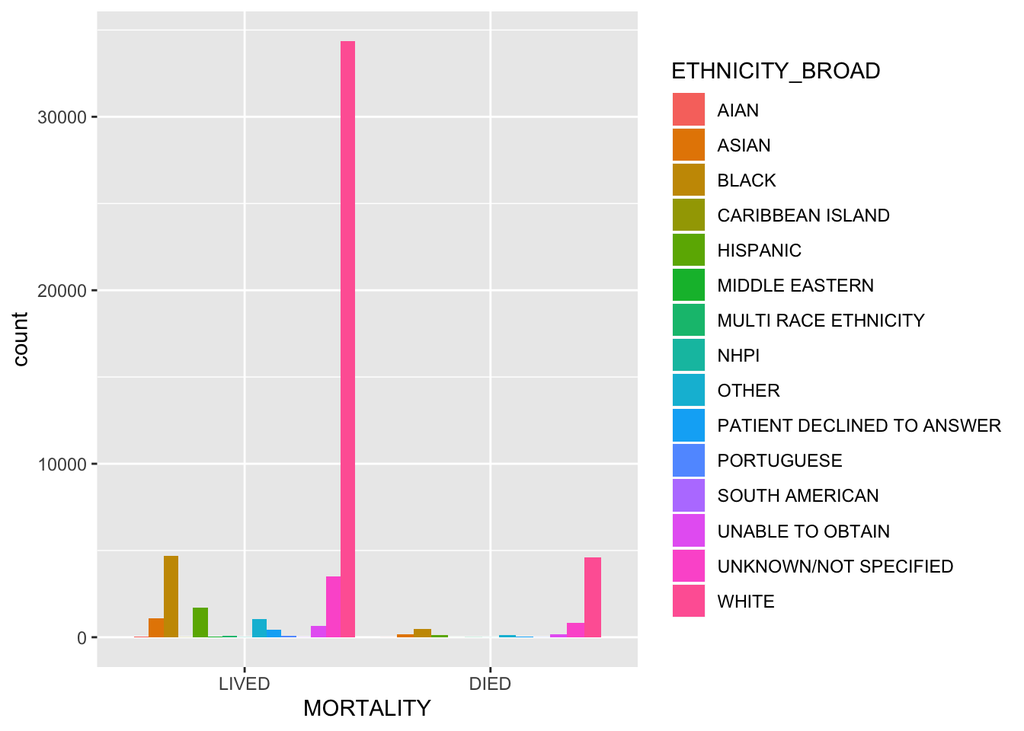

```r
summary(patients_recoded_trim$ETHNICITY_BROAD)
##                       AIAN                      ASIAN                      BLACK           CARIBBEAN ISLAND                   HISPANIC             MIDDLE EASTERN       MULTI RACE ETHNICITY                       NHPI                      OTHER PATIENT DECLINED TO ANSWER                 PORTUGUESE             SOUTH AMERICAN           UNABLE TO OBTAIN      UNKNOWN/NOT SPECIFIED
##                         28                       1263                       5173                          9                       1838                         41                        110                         14                       1198                        467                         67                          8                        843                       4327
##                      WHITE
##                      38976

ggplot(patients_recoded_trim, aes(x = MORTALITY, fill = ETHNICITY_BROAD)) +
  geom_bar(aes(fill = ETHNICITY_BROAD), position = "dodge")
```

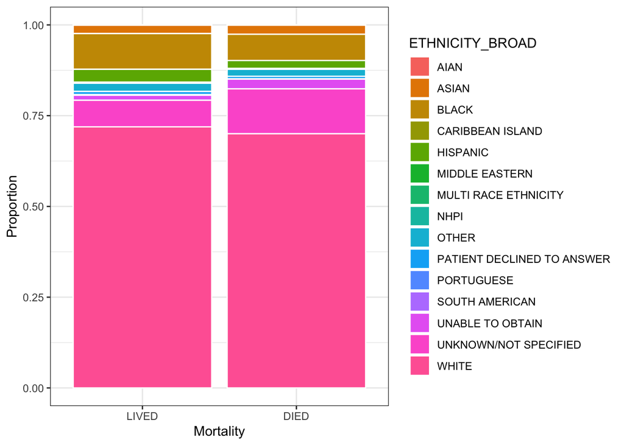

```r
  #scale_fill_manual(values = c(Grey, Yellow, PennRed))

ggplot(data = patients_recoded_trim, aes(x = MORTALITY, fill = ETHNICITY_BROAD)) +
    geom_bar(position = "fill", color = "white") +
  #scale_fill_manual(values = c(Green, DarkBlue)) +
  theme_bw() +
  labs(y = "Proportion", x = "Mortality")
```

```r
# ETHNICITY_BROAD as predictor
summary((glm(MORTALITY ~ ETHNICITY_BROAD, data = patients_recoded_trim, family = binomial()))) # 0.00226
##
## Call:
## glm(formula = MORTALITY ~ ETHNICITY_BROAD, family = binomial(),
##     data = patients_recoded_trim)
##
## Deviance Residuals:
##     Min       1Q   Median       3Q      Max
## -0.8203  -0.5015  -0.5015  -0.4502   2.4578
##
## Coefficients:
##                                             Estimate Std. Error z value Pr(>|z|)
## (Intercept)                                -2.120264   0.611010  -3.470  0.00052 ***
## ETHNICITY_BROADASIAN                        0.224963   0.616688   0.365  0.71527
## ETHNICITY_BROADBLACK                       -0.168998   0.612901  -0.276  0.78275
## ETHNICITY_BROADCARIBBEAN ISLAND           -10.445799 108.249623  -0.096  0.92313
## ETHNICITY_BROADHISPANIC                    -0.359937   0.617224  -0.583  0.55979
## ETHNICITY_BROADMIDDLE EASTERN              -0.850151   0.948143  -0.897  0.36991
## ETHNICITY_BROADMULTI RACE ETHNICITY        -0.297632   0.703097  -0.423  0.67206
## ETHNICITY_BROADNHPI                         1.203973   0.850490   1.416  0.15689
## ETHNICITY_BROADOTHER                        0.005597   0.618078   0.009  0.99277
## ETHNICITY_BROADPATIENT DECLINED TO ANSWER  -0.118079   0.630813  -0.187  0.85151
## ETHNICITY_BROADPORTUGUESE                  -0.198851   0.745918  -0.267  0.78979
## ETHNICITY_BROADSOUTH AMERICAN             -10.445799 114.815861  -0.091  0.92751
## ETHNICITY_BROADUNABLE TO OBTAIN             0.787957   0.616858   1.277  0.20147
## ETHNICITY_BROADUNKNOWN/NOT SPECIFIED        0.654969   0.612249   1.070  0.28472
## ETHNICITY_BROADWHITE                        0.110193   0.611212   0.180  0.85693
## ---
## Signif. codes:  0 '***' 0.001 '**' 0.01 '*' 0.05 '.' 0.1 ' ' 1
##
## (Dispersion parameter for binomial family taken to be 1)
##
##     Null deviance: 40095  on 54361  degrees of freedom
## Residual deviance: 39782  on 54347  degrees of freedom
## AIC: 39812
##
## Number of Fisher Scoring iterations: 11
```

- There is no significant association between any particular `ETHNICITY_BROAD` and `MORTALITY`

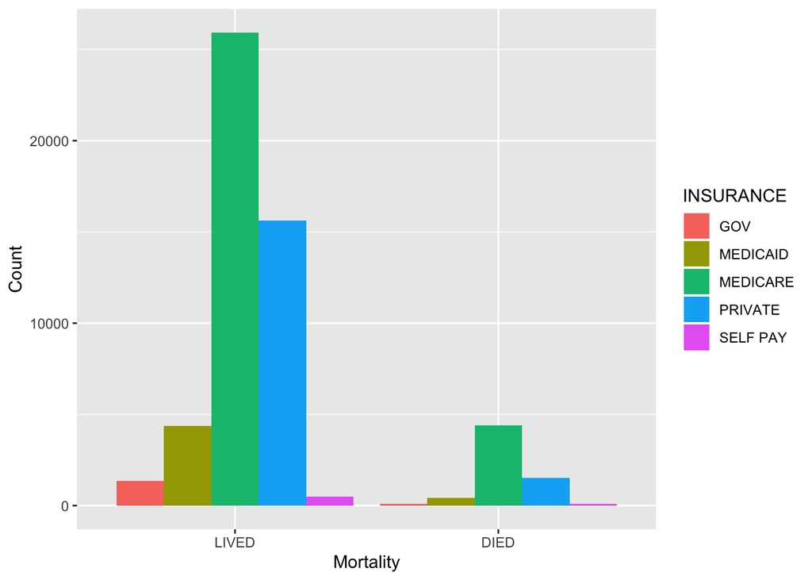

```r
summary(patients_recoded_trim$INSURANCE)
##      GOV MEDICAID MEDICARE  PRIVATE SELF PAY
##     1461     4801    30346    17168      586

# standard bar plot
ggplot(patients_recoded_trim, aes(x = MORTALITY, fill = INSURANCE)) +
  geom_bar(aes(fill = INSURANCE), position = "dodge") +
  labs(y = "Count", x = "Mortality")
```

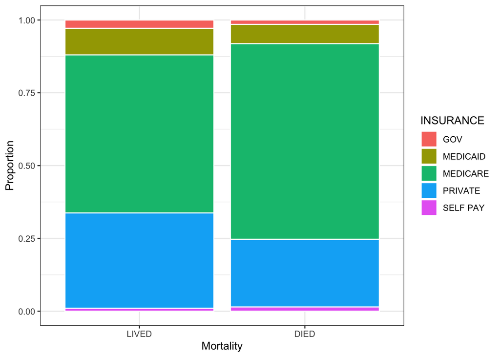

```r
  #scale_fill_manual(values = c(Grey, Yellow, PennRed)) +

# stacked bar plot
ggplot(data = patients_recoded_trim, aes(x = MORTALITY, fill = INSURANCE)) +
    geom_bar(position = "fill", color = "white") +
  #scale_fill_manual(values = c(Green, DarkBlue)) +
  theme_bw() +
  labs(y = "Proportion", x = "Mortality")
```

```r
# INSURANCE_TYPE as predictor
summary((glm(MORTALITY ~ INSURANCE, data = patients_recoded_trim, family = binomial())))
##
## Call:
## glm(formula = MORTALITY ~ INSURANCE, family = binomial(), data = patients_recoded_trim)
##
## Deviance Residuals:
##     Min       1Q   Median       3Q      Max
## -0.6016  -0.5608  -0.4353  -0.4318   2.3202
##
## Coefficients:
##                   Estimate Std. Error z value Pr(>|z|)
## (Intercept)        -2.6216     0.1041 -25.185  < 2e-16 ***
## INSURANCEMEDICAID   0.3128     0.1156   2.705  0.00682 **
## INSURANCEMEDICARE   0.8514     0.1054   8.081 6.41e-16 ***
## INSURANCEPRIVATE    0.2957     0.1075   2.751  0.00594 **
## INSURANCESELF PAY   1.0039     0.1523   6.593 4.32e-11 ***
## ---
## Signif. codes:  0 '***' 0.001 '**' 0.01 '*' 0.05 '.' 0.1 ' ' 1
##
## (Dispersion parameter for binomial family taken to be 1)
##
##     Null deviance: 40095  on 54361  degrees of freedom
## Residual deviance: 39651  on 54357  degrees of freedom
## AIC: 39661
##
## Number of Fisher Scoring iterations: 5
```

- There is a signficant association between all `INSURANCE` and `MORTALITY` (i.e. having any insurance)

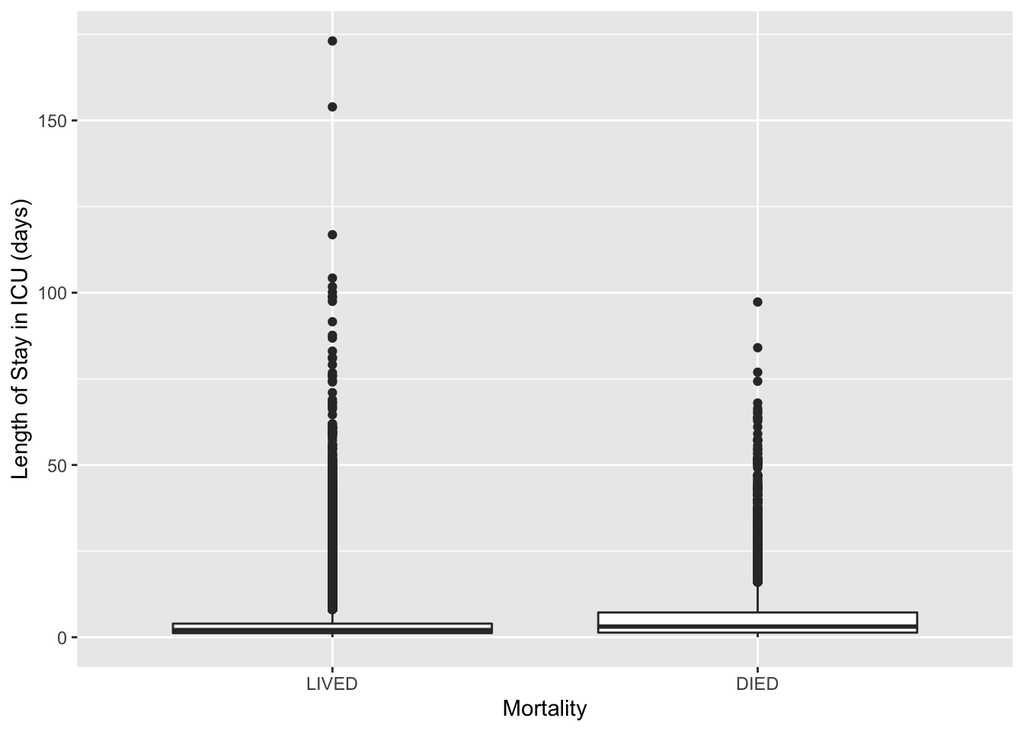

```r
# Length of stay (LOS) in the ICU as predictor
ggplot(data = patients_recoded_trim, aes(x = MORTALITY, y = LOS_ICU)) +
    geom_boxplot() +
  labs(y = "Length of Stay in ICU (days)", x = "Mortality")
```

```r
# LOS_ICU as predictor
summary((glm(MORTALITY ~ LOS_ICU, data = patients_recoded_trim, family = binomial()))) # p-value <2e-16
##
## Call:
## glm(formula = MORTALITY ~ LOS_ICU, family = binomial(), data = patients_recoded_trim)
##
## Deviance Residuals:
##     Min       1Q   Median       3Q      Max
## -3.0241  -0.5003  -0.4855  -0.4778   2.1267
##
## Coefficients:
##             Estimate Std. Error z value Pr(>|z|)
## (Intercept) -2.15138    0.01594 -134.97   <2e-16 ***
## LOS_ICU      0.03879    0.00169   22.95   <2e-16 ***
## ---
## Signif. codes:  0 '***' 0.001 '**' 0.01 '*' 0.05 '.' 0.1 ' ' 1
##
## (Dispersion parameter for binomial family taken to be 1)
##
##     Null deviance: 39661  on 53314  degrees of freedom
## Residual deviance: 39169  on 53313  degrees of freedom
##   (1047 observations deleted due to missingness)
## AIC: 39173
##
## Number of Fisher Scoring iterations: 4
```

- `LOS_ICU` was positively associated with `MORTALITY` with p-value <2e-16

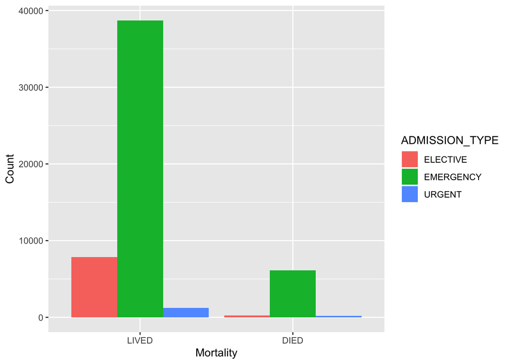

```r
# standard bar plot
ggplot(patients_recoded_trim, aes(x = MORTALITY, fill = ADMISSION_TYPE)) +
  geom_bar(aes(fill = ADMISSION_TYPE), position = "dodge") +
  labs(y = "Count", x = "Mortality")
```

```r
  #scale_fill_manual(values = c(Grey, Yellow, PennRed)) +

# Type of ICU admission as predictor
summary((glm(MORTALITY ~ ADMISSION_TYPE, data = patients_recoded_trim, family = binomial()))) # p-value <2e-16
##
## Call:
## glm(formula = MORTALITY ~ ADMISSION_TYPE, family = binomial(),
##     data = patients_recoded_trim)
##
## Deviance Residuals:
##     Min       1Q   Median       3Q      Max
## -0.5425  -0.5425  -0.5425  -0.2531   2.6294
##
## Coefficients:
##                         Estimate Std. Error z value Pr(>|z|)
## (Intercept)             -3.42484    0.06363  -53.82   <2e-16 ***
## ADMISSION_TYPEEMERGENCY  1.58292    0.06510   24.32   <2e-16 ***
## ADMISSION_TYPEURGENT     1.50678    0.10174   14.81   <2e-16 ***
## ---
## Signif. codes:  0 '***' 0.001 '**' 0.01 '*' 0.05 '.' 0.1 ' ' 1
##
## (Dispersion parameter for binomial family taken to be 1)
##
##     Null deviance: 40095  on 54361  degrees of freedom
## Residual deviance: 39159  on 54359  degrees of freedom
## AIC: 39165
##
## Number of Fisher Scoring iterations: 6
```

- `ADMISSION_TYPE`s EMERGENCY and URGENT were both positively associated with `MORTALITY` with p-value <2e-16

This section summarizes the record count for each variable of interest and calculates the proportion (%).

```r
summary(patients_recoded_trim)
```

```
##    ADMISSION_TYPE     INSURANCE     GENDER       AGE_ADM         AGE_DOD         LOS_ICU                      ETHNICITY_BROAD         DELIVERY            CSECTION     MORTALITY
##  ELECTIVE : 8088   GOV     : 1461   F:23748   Min.   :18.01   Min.   :18.46   Min.   :  0.0001   WHITE                :38976   DELIVERY   :   53   CSECTION   :   41   LIVED:47788
##  EMERGENCY:44853   MEDICAID: 4801   M:30614   1st Qu.:52.90   1st Qu.:60.33   1st Qu.:  1.2063   BLACK                : 5173   NO DELIVERY:54309   NO CSECTION:54321   DIED : 6574
##  URGENT   : 1421   MEDICARE:30346             Median :65.78   Median :72.43   Median :  2.1449   UNKNOWN/NOT SPECIFIED: 4327
##                    PRIVATE :17168             Mean   :64.02   Mean   :70.13   Mean   :  4.1465   HISPANIC             : 1838
##                    SELF PAY:  586             3rd Qu.:77.78   3rd Qu.:82.42   3rd Qu.:  4.1933   ASIAN                : 1263
##                                               Max.   :89.06   Max.   :95.85   Max.   :173.0725   OTHER                : 1198
##                                                               NA's   :37837   NA's   :1047       (Other)              : 1587
```

```r
patients_recoded_trim %>% group_by(MORTALITY, GENDER) %>%
  summarize(COUNT = n(), PROP = round(n()/54362*100,2))
```

```
## # A tibble: 4 x 4
## # Groups:   MORTALITY [2]
##   MORTALITY GENDER COUNT  PROP
##   <fct>     <fct>  <int> <dbl>
## 1 LIVED     F      20761 38.2
## 2 LIVED     M      27027 49.7
## 3 DIED      F       2987  5.49
## 4 DIED      M       3587  6.6
```

```r
patients_recoded_trim %>% group_by(MORTALITY, INSURANCE) %>%
  summarize(COUNT = n(), PROP = round(n()/54362*100,2))
```

```
## # A tibble: 10 x 4
## # Groups:   MORTALITY [2]
##    MORTALITY INSURANCE COUNT  PROP
##    <fct>     <fct>     <int> <dbl>
##  1 LIVED     GOV        1362  2.51
##  2 LIVED     MEDICAID   4367  8.03
##  3 LIVED     MEDICARE  25930 47.7
##  4 LIVED     PRIVATE   15640 28.8
##  5 LIVED     SELF PAY    489  0.9
##  6 DIED      GOV          99  0.18
##  7 DIED      MEDICAID    434  0.8
##  8 DIED      MEDICARE   4416  8.12
##  9 DIED      PRIVATE    1528  2.81
## 10 DIED      SELF PAY     97  0.18
```

```r
patients_recoded_trim %>% group_by(MORTALITY, ADMISSION_TYPE) %>%
  summarize(COUNT = n(), PROP = round(n()/54362*100,2))
```

```
## # A tibble: 6 x 4
## # Groups:   MORTALITY [2]
##   MORTALITY ADMISSION_TYPE COUNT  PROP
##   <fct>     <fct>          <int> <dbl>
## 1 LIVED     ELECTIVE        7833 14.4
## 2 LIVED     EMERGENCY      38716 71.2
## 3 LIVED     URGENT          1239  2.28
## 4 DIED      ELECTIVE         255  0.47
## 5 DIED      EMERGENCY       6137 11.3
## 6 DIED      URGENT           182  0.33
```

```r
patients_recoded_trim %>% group_by(MORTALITY, ETHNICITY_BROAD) %>%
  summarize(COUNT = n(), PROP = round(n()/54362*100,2))
```

```
## # A tibble: 28 x 4
## # Groups:   MORTALITY [2]
##    MORTALITY ETHNICITY_BROAD            COUNT  PROP
##    <fct>     <fct>                      <int> <dbl>
##  1 LIVED     AIAN                          25  0.05
##  2 LIVED     ASIAN                       1098  2.02
##  3 LIVED     BLACK                       4697  8.64
##  4 LIVED     CARIBBEAN ISLAND               9  0.02
##  5 LIVED     HISPANIC                    1696  3.12
##  6 LIVED     MIDDLE EASTERN                39  0.07
##  7 LIVED     MULTI RACE ETHNICITY         101  0.19
##  8 LIVED     NHPI                          10  0.02
##  9 LIVED     OTHER                       1069  1.97
## 10 LIVED     PATIENT DECLINED TO ANSWER   422  0.78
## # … with 18 more rows
```

```r
patients_recoded_trim %>% group_by(MORTALITY, DELIVERY, GENDER) %>%
  summarize(COUNT = n(), PROP = round(n()/54362*100,2))
```

```
## # A tibble: 5 x 5
## # Groups:   MORTALITY, DELIVERY [3]
##   MORTALITY DELIVERY    GENDER COUNT  PROP
##   <fct>     <fct>       <fct>  <int> <dbl>
## 1 LIVED     DELIVERY    F         53  0.1
## 2 LIVED     NO DELIVERY F      20708 38.1
## 3 LIVED     NO DELIVERY M      27027 49.7
## 4 DIED      NO DELIVERY F       2987  5.49
## 5 DIED      NO DELIVERY M       3587  6.6
```

```r
patients_recoded_trim %>% group_by(MORTALITY, CSECTION, GENDER) %>%
  summarize(COUNT = n(), PROP = round(n()/54362*100,2))
```

```
## # A tibble: 5 x 5
## # Groups:   MORTALITY, CSECTION [3]
##   MORTALITY CSECTION    GENDER COUNT  PROP
##   <fct>     <fct>       <fct>  <int> <dbl>
## 1 LIVED     CSECTION    F         41  0.08
## 2 LIVED     NO CSECTION F      20720 38.1
## 3 LIVED     NO CSECTION M      27027 49.7
## 4 DIED      NO CSECTION F       2987  5.49
## 5 DIED      NO CSECTION M       3587  6.6
```

```r
patients_recoded_trim %>% group_by(MORTALITY) %>% summarize(COUNT = n(), PROP = round(n()/54362*100,2))
```

```
## # A tibble: 2 x 3
##   MORTALITY COUNT  PROP
##   <fct>     <int> <dbl>
## 1 LIVED     47788  87.9
## 2 DIED       6574  12.1
```

- From the summarized data it is clear that there are no records of patients that died within the hospital and also delivered a child during their care. Subsequently there are also no records of patients that died within the hospital and delivered a child via a C-section procedure.
- Therefore, any logistic model assessing `DELIVERY` or `CSECTION` as a predictor of `MORTALITY` will be inadequate, as evidenced below.

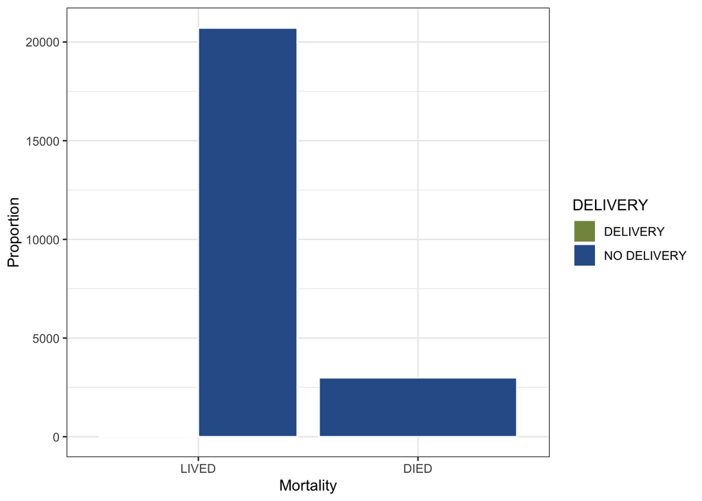

```r
# narrowing down to female patients
patients_recoded_trim_f <- patients_recoded_trim %>% filter(GENDER == "F")

ggplot(data = patients_recoded_trim_f, aes(x = MORTALITY, fill = DELIVERY)) +
    geom_bar(position = "dodge", color = "white") +
  scale_fill_manual(values = c(Green, DarkBlue)) +
  theme_bw() +
  labs(y = "Proportion", x = "Mortality")
```

```r
# Delivery as predictor
summary((glm(MORTALITY ~ DELIVERY, data = patients_recoded_trim_f, family = binomial()))) # 0.00226
##
## Call:
## glm(formula = MORTALITY ~ DELIVERY, family = binomial(), data = patients_recoded_trim_f)
##
## Deviance Residuals:
##     Min       1Q   Median       3Q      Max
## -0.5191  -0.5191  -0.5191  -0.5191   2.0352
##
## Coefficients:
##                     Estimate Std. Error z value Pr(>|z|)
## (Intercept)           -14.57     121.25  -0.120    0.904
## DELIVERYNO DELIVERY    12.63     121.25   0.104    0.917
##
## (Dispersion parameter for binomial family taken to be 1)
##
##     Null deviance: 17967  on 23747  degrees of freedom
## Residual deviance: 17953  on 23746  degrees of freedom
## AIC: 17957
##
## Number of Fisher Scoring iterations: 13
```

- There is a **non-significant** positive association between `NO DELIVERY` and `MORTALITY`

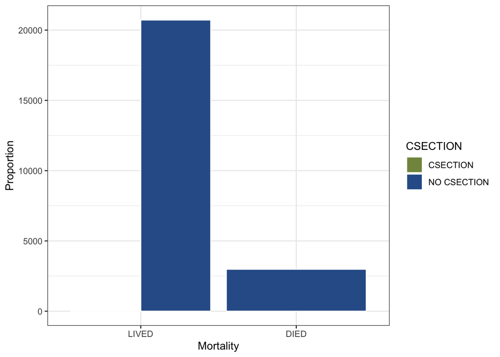

```r
ggplot(data = patients_recoded_trim_f, aes(x = MORTALITY, fill = CSECTION)) +
    geom_bar(position = "dodge", color = "white") +
  scale_fill_manual(values = c(Green, DarkBlue)) +
  theme_bw() +
  labs(y = "Proportion", x = "Mortality")
```

```r
# C-section as predictor
summary((glm(MORTALITY ~ CSECTION, data = patients_recoded_trim_f, family = binomial()))) # 0.00226
##
## Call:
## glm(formula = MORTALITY ~ CSECTION, family = binomial(), data = patients_recoded_trim_f)
##
## Deviance Residuals:
##    Min      1Q  Median      3Q     Max
## -0.519  -0.519  -0.519  -0.519   2.035
##
## Coefficients:
##                     Estimate Std. Error z value Pr(>|z|)
## (Intercept)           -14.57     137.86  -0.106    0.916
## CSECTIONNO CSECTION    12.63     137.86   0.092    0.927
##
## (Dispersion parameter for binomial family taken to be 1)
##
##     Null deviance: 17967  on 23747  degrees of freedom
## Residual deviance: 17956  on 23746  degrees of freedom
## AIC: 17960
##
## Number of Fisher Scoring iterations: 13
```

- There is a **non-significant** positive association between `NO CSECTION` and `MORTALITY`

#### Logistic regression

This section uses a logistic regression model that includes all variables of interest as predictors of `MORTALITY`.

```r
# narrowing to only binary variables of interest
patients_recoded_trim_glm <- patients_recoded_trim %>% select(-(AGE_ADM:LOS_ICU),-(DELIVERY:CSECTION))

# logistic regression model
patients_glm <- glm(MORTALITY ~ ., data = patients_recoded_trim_glm, family = binomial(logit))
summary(patients_glm)
##
## Call:
## glm(formula = MORTALITY ~ ., family = binomial(logit), data = patients_recoded_trim_glm)
##
## Deviance Residuals:
##     Min       1Q   Median       3Q      Max
## -0.9737  -0.5840  -0.4684  -0.2801   2.8762
##
## Coefficients:
##                                            Estimate Std. Error z value Pr(>|z|)
## (Intercept)                                -4.15335    0.62791  -6.615 3.73e-11 ***
## ADMISSION_TYPEEMERGENCY                     1.57625    0.06539  24.106  < 2e-16 ***
## ADMISSION_TYPEURGENT                        1.33293    0.10337  12.895  < 2e-16 ***
## INSURANCEMEDICAID                           0.31426    0.11637   2.700  0.00692 **
## INSURANCEMEDICARE                           0.83866    0.10649   7.875 3.40e-15 ***
## INSURANCEPRIVATE                            0.32630    0.10861   3.004  0.00266 **
## INSURANCESELF PAY                           0.84804    0.15375   5.516 3.48e-08 ***
## GENDERM                                    -0.04023    0.02703  -1.489  0.13659
## ETHNICITY_BROADASIAN                        0.27761    0.62117   0.447  0.65494
## ETHNICITY_BROADBLACK                       -0.25300    0.61728  -0.410  0.68191
## ETHNICITY_BROADCARIBBEAN ISLAND           -10.23166  104.82831  -0.098  0.92225
## ETHNICITY_BROADHISPANIC                    -0.32122    0.62163  -0.517  0.60534
## ETHNICITY_BROADMIDDLE EASTERN              -0.69027    0.95316  -0.724  0.46895
## ETHNICITY_BROADMULTI RACE ETHNICITY        -0.26503    0.70815  -0.374  0.70821
## ETHNICITY_BROADNHPI                         1.23847    0.86305   1.435  0.15129
## ETHNICITY_BROADOTHER                        0.08308    0.62261   0.133  0.89384
## ETHNICITY_BROADPATIENT DECLINED TO ANSWER   0.13604    0.63587   0.214  0.83059
## ETHNICITY_BROADPORTUGUESE                  -0.18227    0.75153  -0.243  0.80837
## ETHNICITY_BROADSOUTH AMERICAN             -10.33786  113.76934  -0.091  0.92760
## ETHNICITY_BROADUNABLE TO OBTAIN             0.75670    0.62145   1.218  0.22337
## ETHNICITY_BROADUNKNOWN/NOT SPECIFIED        0.64818    0.61680   1.051  0.29332
## ETHNICITY_BROADWHITE                        0.09633    0.61571   0.156  0.87568
## ---
## Signif. codes:  0 '***' 0.001 '**' 0.01 '*' 0.05 '.' 0.1 ' ' 1
##
## (Dispersion parameter for binomial family taken to be 1)
##
##     Null deviance: 40095  on 54361  degrees of freedom
## Residual deviance: 38444  on 54340  degrees of freedom
## AIC: 38488
##
## Number of Fisher Scoring iterations: 11

# There were signficant positive associations between all insurance types and MORTALITY

glm_pred <- predict(patients_glm, patients_recoded_trim_glm, type = "response")
head(glm_pred)
##          1          2          3          4          5          6
## 0.10391499 0.03701932 0.15678594 0.10022791 0.10022791 0.24407029

table(glm_pred > 0.5) # 0 admissions had probability > 0.5
##
## FALSE
## 54362
```

#### Model Evaluation

This section performs a 10-fold cross-validation of the model

```r
#K-Fold Cross Validation
N = nrow(patients_recoded_trim_glm)
K = 10
set.seed(1234)
s = sample(1:K, size = N, replace = T)
pred.outputs.glm <- vector(mode = "numeric", length = N)
obs.outputs <- vector(mode = "numeric", length = N)
offset <- 0
for(i in 1:K){
    train <- filter(patients_recoded_trim_glm, s != i)
    test <- filter(patients_recoded_trim_glm, s == i)
  obs.outputs[1:length(s[s == i]) + offset] <- test$MORTALITY

  #GLM train/test
    glm <- glm(MORTALITY ~ ., data = train, family = binomial(logit))
  glm.pred.curr <- predict(glm, test, type = "response")
  pred.outputs.glm[1:length(s[s == i]) + offset] <- glm.pred.curr

    offset <- offset + length(s[s == i])
}
head(pred.outputs.glm)
```

```
## [1] 0.15691302 0.16198077 0.09982316 0.03707570 0.15691302 0.18520605
```

```r
table(pred.outputs.glm > .5) # No admissions had probability > 0.5
```

```
##
## FALSE
## 54362
```

```r
library(pROC)
roc(patients_recoded_trim_glm$MORTALITY, glm_pred, ci = TRUE) # AOC: 0.6399
```

```
##
## Call:
## roc.default(response = patients_recoded_trim_glm$MORTALITY, predictor = glm_pred,     ci = TRUE)
##
## Data: glm_pred in 47788 controls (patients_recoded_trim_glm$MORTALITY LIVED) < 6574 cases (patients_recoded_trim_glm$MORTALITY DIED).
## Area under the curve: 0.6399
## 95% CI: 0.6333-0.6465 (DeLong)
```

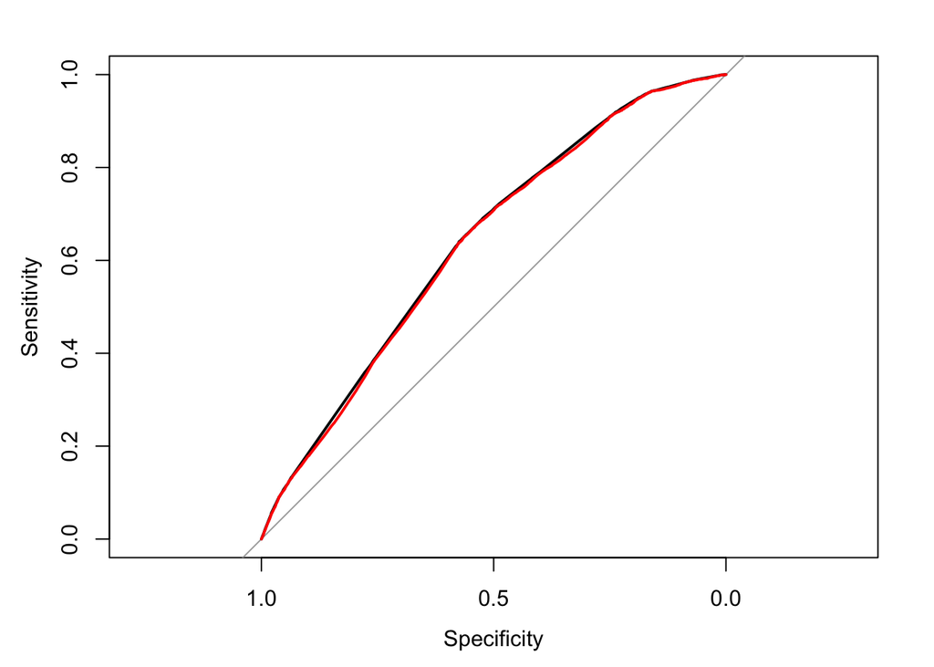

```r
plot.roc(patients_recoded_trim_glm$MORTALITY, glm_pred, ci = TRUE)
plot.roc(obs.outputs, pred.outputs.glm, col = "red", add = TRUE)
```

- An area under the curve (AUC) of 0.6399 showed the logistic model was slightly better at fitting the admissions data than chance (~0.5).

#### Conclusions and Limitations

- The logistic model as utilized in this project was not an ideal for the admissions data in the MIMIC-III database. Approaching the analysis of mortality as a binary outcome might benefit from exploration using a random forest classifier, potentially in addition to regularization of the data to identify the most important variables in the dataset.
- The patient population is mostly of an age beyond the reproductive lifespan, which means fewer pregnancies, particularly those unassisted by Artificial Reproductive Technology, so the MIMIC-III databse is not adequate for studying pregnancy-related outcomes.
- Because all dates in the database have been shifted to protect patient confidentiality, C-section rates could not be compared to national rates reported by the Centers for Disease Control and Prevention (CDC) because years could not be matched. Reference: https://mimic.physionet.org/mimicdata/time/
  - Date shifting removed:
    - Year: The year was randomly distributed between 2100 and 2200
    - Day of the month: The absolute day of the month is not preserved (though the day of the week is)
    - Inter-patient information: Meaning two patients in the ICU on the same date were not actually in the ICU at the same time
- Not all `ICD9_CODES` in the MIMIC-III database matched to an exisiting ICD code, which reduced the number of records available for analysis.

### References

- Johnson, A., Pollard, T., Mark, R. (2016) MIMIC-III, a freely accessible critical care database. Scientific Data (2016). DOI: 10.1038/sdata.2016.35. Available from: http://www.nature.com/articles/sdata201635